# Entrada de dados (KeyEntry App)

Versão 1.0.1

Rafael Posada

17 Outubro 2017

# 1 Introdução

O Aplicativo de *Entrada de Dados* (keyEntry-App) foi desenvolvido no âmbito da iniciativa SASSCAL (http://www.sasscal.org) através da tarefa climática *Gerenciamento de dados climáticos historicos e actuais* para facilitar a entrada de dados climáticos nos serviços meteorológicos de Angola, Botswana E Zâmbia.

O aplicativo fornece ao usuário uma interface baseada na web para inserir os dados da mesma maneira que eles estão no formulário em papel. O usuário também pode personalizar a estrutura dos formulários e criar seus próprios modelos. Inclui um controle de qualidade in-situ com base em limites absolutos, de modo que o usuário esteja ciente se um valor inserido estiver fora dos limites.

A ferramenta foi desenvolvida sob Shiny, um pacote de código aberto R que fornece uma estrutura web para a construção de aplicativos da web usando R (https://shiny.rstudio.com/). Shiny ajuda a transformar as análises de dados em aplicações web interativas sem requerer conhecimento em HTML, CSS ou JavaScript (RStudio, 2017)

Este manual dará uma visão geral do aplicativo, explicando como instalá-lo, como executá-lo e como usá-lo.

# 2 Requisitos

## 2.1 Requisitos de software

O seguinte software é necessários para a instalação do aplicativo:

- Windows 7 ou superior
- Java SE Runtime Environment 7 ou superior (http://www.oracle.com/technetwork/java/javase/downloads/index.html)
- R v3.2.1 ou superior (https://cran.r-project.org/bin/windows/base/)
- RStudio v0.99.467 ou superior (https://www.rstudio.com/products/rstudio/download/)
- Rtools v.3.2 ou superior (https://cran.r-project.org/bin/windows/Rtools/)
- Um navegador da Web, como Mozilla-Firefox, Chrome ou Internet Explorer (v.11 ou superior)

Além deste software, pare que o aplicativo seja totalmente operacional também exige programas adicionais:

- Pandoc (http://pandoc.org/): um conversor de documento universal. Será necessário para criar os arquivos de ajuda.

Se este programa não estiver disponível no *localhost*, o aplicativo irá instalá-lo automaticamente. A tabela a seguir mostra a versão padrão que o aplicativo irá instalar, asi como os links para o arquivo de download. O usuário pode instalar uma versão posterior do software a qualquer momento.

| Programa | Versão padrão | Link para baixar o programa |
| --- | --- | --- |
| Pandoc | 1.19.2.1 | http://pandoc.org/installing.html |

## 2.2 Pacotes do R

O pacote é a unidade fundamental do código compartilhável em R. Um pacote agrupa código, dados, documentação, etc. e é fácil de compartilhar com os outros Wickham, 2017.

O aplicativo `keyEntry` requer uma série de pacotes R para serem executados corretamente. A maioria deles está disponível on-line e será instalada automaticamente pela aplicação. Esses pacotes são:

```
## installr
## jsonlite
## mailR
```

```
## rhandsontable
## rmarkdown
## shiny
```

```
## shinyBS
## uuid
## XLConnect
```

Os pacotes são salvos no seguinte caminho:

```
## keyEntry_standalone/keyEntry_App/www/R_pkgs/win.binary
```

# 3 Instalação e desinstalação

> **Nota:** Execute a instalação como **Administrador**.

## 3.1 Instalação

O aplicativo é armazenado como um arquivo `.zip` para reduzir o tamanho do mesmo. Existem dois arquivos `.zip` diferentes disponíveis:

- `keyEntry_compact_small.zip` (aprox. 9 Mb): Contém as informações mínimas para instalar o aplicativo. O **usuário precisará de conexão a Internet para completar a instalação**, uma vez que o aplicativo terá que baixar o R-Packages de um repositório R-CRAN (geralmente o repositório: http://cran.us.r-project.org) e o Software necessário (ou seja, Pandoc)
- `keyEntry_compact_large.zip` (aprox. 49 Mb): Contém todos os R-Pacotes e software necessários para a instalação da aplicação. O **usuário não precisará de conexão a Internet**.

Para prosseguir com a instalação, o usuário deve seguir estes passos:

1. **Descompactação do arquivo**: O usuário tem que descompactar o arquivo `keyEntry_compact_small.zip` ou `keyEntry_compact_large.zip` e colocar o conteúdo em qualquer pasta (por exemplo Desktop, Documentsou qualquer outro).
2. **Abrir a pasta KeyEntry_standalone**: Esta pasta contém todos os arquivos para instalar e executar o aplicativo.
3. **Editar o arquivo keyEntry.bat**: Clique com o botão direito do mouse nesse arquivo e selecione `Edit`. Um editor abrirá o arquivo `.bat` e o usuário terá que modificar o caminho onde `R` está localizado. O caminho padrão é:

   ```
   ## C:/Program Files/R/R-3.2.1/bin/i386
   ```

   Onde `R-3.2.1` é a versão de `R`, and `i386` contém a versão `32bit` de `R`. Uma vez que as alterações foram feitas, salve as alterações e feche o Editor.
4. **Execute keyEntry.bat**: Clique duas vezes no arquivo. Uma janela de comando será exibida.
5. **Selecione Serviço Meteorológico**: O usuário será solicitado a digitar o serviço meteorológico (`DMS`, `INAMET` ou `ZMD`). Esta informação deve ser inserida apenas uma vez: durante o processo de instalação.

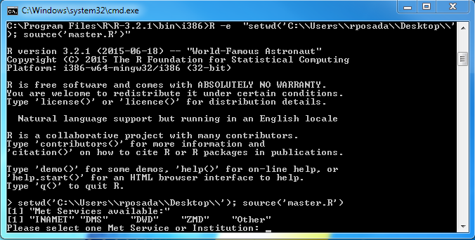

Figure 1. Select the Meteorological Service

6. **Baixada dos pacotes:** se o usuário usar o arquivo `keyEntry_compact_small.zip`, o aplicativo baixará automaticamente os R-Packages necessários de um repositório R-CRAN. Caso contrário, o aplicativo conterá já os pacotes necessários. Os pacotes serão salvos em:

   ```
   ## keyEntry_standalone/keyEntry_App/www/R_pkgs/win.binary
   ```

   > **Nota:** Este passo pode demorar alguns minutos. Por favor, seja paciente.
7. **Instalação das bibliotecas:** Uma vez que os pacotes são salvos localmente, o aplicativo procederá a descompactar e instalar os pacotes como bibliotecas. Essas bibliotecas estarão localizadas em:

   ```
   ## keyEntry_standalone/keyEntry_App/www/libraries
   ```

   > **Nota:** Este passo pode demorar alguns minutos. Por favor, seja paciente.
8. **Baixada e instalação de Pandoc:** Se não estiver disponível na pasta `keyEntry_standalone` folder, o arquivo instalador de `Pandoc` será baixado da Internet. Uma vez que o arquivo do instalador esteja disponível, ele será executado automaticamente para que o assistente de instalação apareça. O usuário terá que seguir as etapas do assistente.

Uma vez que o processo de instalação está concluído, o `keyEntry-App` abrir-se-á automaticamente.

## 3.2 Desinstalação

Para desinstalar o aplicativo, basta remover a pasta `keyEntry_standalone`.

# 4 Execução do Aplicativo

Para executar o aplicativo, basta clicar duas vezes no arquivo `KeyEntry.bat`. Após alguns segundos, um navegador da Web é aberto. A interface KeyEntry-App aparece diretamente no navegador Web.

> **NOTA IMPORTANTE**

> *Se mais de um usuário irá trabalhar com o App, ao mesmo tempo, recomenda-se para criar sessões diferentes, um para cada usuário. Para fazer isso, você deve modificar uma linha de comando no arquivo `keyEntry.bat`.*

> *Onde diz `set users = 1`, substitua o número`1` pelo número de usuários que serão conectados ao aplicativo (veja a Figura 2).*

> *Cada sessão terá um número de porta diferente (`30XX`) onde`XX` é o número de usuário. Por exemplo, se `users` estiver configurado para`10`, haverá dez portas disponíveis (de `3001` a`3010`). O número máximo de usuários é `99`.*

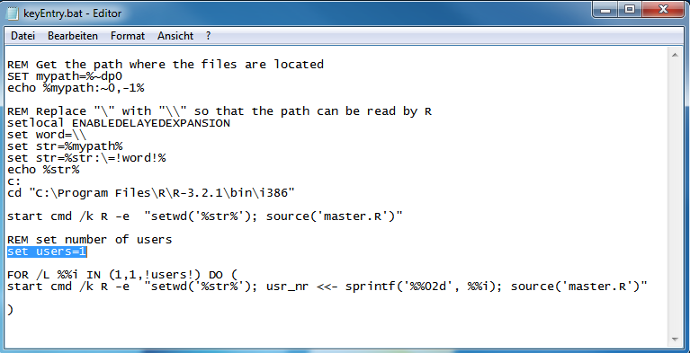

Figura 2. Configurar o número de usuários que vão trabalhar com a aplicação

Uma vez que o usuário está no navegador da Web, terá que selecionar o formulário em que os dados devem ser introduzidos. Depois de selecionar o formulário, novos campos são exibidos para completar a entrada de metadados adicionais, como identificação da estação, data ou nome da pessoa que está inserindo os dados. Uma vez preenchidos todos os campos, el botão `Criar` aparece.

Uma vez que o usuário pressiona `Criar`, duas guias aparecem:

- **Formulário:** Contendo o formulário de entrada de chave real
- **Limites e Factores de Escala:** Contendo os limites mínimos e máximos aceitos pela aplicação, bem como o fator de escala de cada elemento

Nas seções a seguir, ambas optões serão explicadas mais detalhadamente.

> **Nota:** O `keyEntry-App` também pode ser acessado a partir de outros computadores conectados à Intranet. Para acessar o aplicativo a partir de outro PC, abra um navegador (por exemplo, Mozilla) e digite o seguinte endereço IP:

```
## http://141.38.15.235:30XX
```

> *onde `30XX` é o número da porta e`XX` refere-se ao número do usuário.*

# 5 Formulário

O Formulário contém uma tabela na qual o usuário pode realmente inserir os dados (veja a Figura 3). A estrutura desta tabela é definida anteriormente em um arquivo do Excel, mas é baseada na estrutura do formulário no papel original (veja a Seção ‘Criar Modelo’ para mais detalhes).

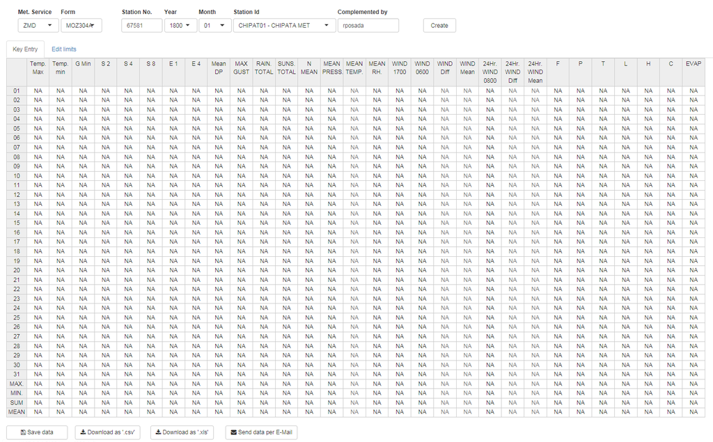

Figura 3. Exemplo de um formulário de entrada de chave

## 5.1 Guardar dados

Os dados inseridos são salvos automaticamente toda vez que o usuário entra um novo valor. Isso garante que os dados não serão perdidos se, por exemplo, o usuário fechar o navegador acidentalmente ou se o computador desligar inesperadamente.

Alternativamente, o usuário pode salvar os dados manualmente pressionando o botão `Salvar dados`. Em seguida, um arquivo Excel ( `.xls`) com os dados será criado e salvo no caminho seguinte:

```
## keyEntry_standalone/keyEntry_App/www/tmp_files
```

As informações contidas no `.xls` arquivo são divididas em quatro folias:

- **metadata:** contendo as informações relacionadas com os metadados, como o ID da estação, nome do formulário, pessoa de contato ou data quando o arquivo foi criado
- **data:** contendo os dados inseridos pelo usuário
- **limits:** contendo os limites aplicados ao formulário e o fator de escala de cada elemento que está disponível no formulário
- **climsoft:** contendo relacionado ao CLIMSOFT (isto é, abreviatura de elemento, unidades, período de tempo, código de elemento, etc.). **Esta folia é essencial para depois importar os dados para CLIMSOFT com sucesso**

> **Nota:** Recomenda-se que o usuário aperte o Save databotão depois que um formulário for concluído.

## 5.2 Baixar os dados

Para baixar os dados inseridos, o usuário tem duas opções:

- Baixar como `.csv`: O usuário obterá os dados em um arquivo separado por vírgulas. Só obterá os dados. Metadados e limites são ignorados.
- Baixe como `.xls`: O usuário receberá os metadados, dados e limites em um arquivo do Excel. A estrutura deste arquivo é a mesma que a descrita acima (see ‘Guardar dados’)

## 5.3 Enviar os dados por E-Mail

O usuário também pode enviar os dados por E-Mail. Se o usuário selecionar esta opção pressionando o botão `Enviar dados por E-Mail`, uma nova janela será exibida. A nova janela espera que o usuário selecione uma conta de E-Mail a partir da qual os dados podem ser enviados e outra conta de E-mail para a qual enviar o E-mail. A senha do remetente é necessária para enviar os dados com sucesso.

O e-mail será gerado automaticamente e conterá os dados em duas formas: como um `.csv` arquivo e como um `.xls` arquivo.

> **Nota:** O endereço de E-Mail do remetente deve ser uma Conta do **GMAIL**. Essa conta precisa ser configurada para permitir que ‘aplicativos menos seguros acessem sua conta’ (veja https://support.google.com/accounts/answer/6010255?hl=pt_BR para obter mais detalhes)

# 6 Edição de Limites e Factores de Escala

## 6.1 Limites

Para tornar as mudanças efetivas, o usuário terá que pressionar o botão Create. **Essas alterações são aplicadas somente no formulário atual**. Isso significa que os novos formulários permanecerão com os limites do padrão. Se o usuário quiser modificar os limites para cada formulário, as mudanças devem ser feitas no modelo de formulário (consulte a Seção ‘Modelo de formulário’ para obter mais detalhes).

Se o usuário insere um valor além dos limites definidos na tabela `Edição de Limites`, a célula ficará vermelha. Desta forma, o usuário estará ciente de que o valor não satisfaz o controle do limite absoluto. É o usuário o que tem que decidir se o valor está realmente correto ou não. Caso contrário, o valor corrigido deve ser inserido. Se estiver correto, recomenda-se que o usuário adapte os limites desse valor.

## 6.2 Factores de Escala

O fator de escala refere-se a um multiplicador que deve ser aplicado ao valor inserido para obter o valor final observado correto.

**Exemplo:** é usual inserir valores de temperatura sem separadores decimais. Isto significa que o usuário entra a uma temperatura de 25,7 C como 257. Para recuperar o valor observado correto (25,7), precisamos multiplicar o valor inserido por `0,1`. Este valor `0,1` é o *factor de escala* da temperatura.

[figure not shown]

Figura 4. Exemplo de Limites e fatores de escala

# 7 Modelo de formulario de Excel

A estrutura dos formulários foi desenvolvida com base nos documentos originais no papel, para que eles pareçam tão parecidos quanto possível com os formulários originais. Essa estrutura é definida em um arquivo Excel (`.xls`) cujo nome corresponde ao nome do formulário original (por exemplo, o arquivo `MOZ304A.xlsx` contém as informações de estrutura do formulário `MOZ304A` de ZMD).

Cada arquivo `.xls` inclui a descrição dos elementos a serem inseridos no formulário, bem como as principais entradas necessárias para criar o formulário, como `station_id` ou `date`. Esta informação é armazenada em `planilhas` (`Worksheets`), cada uma das quais é descrita a seguir.

## 7.1 Folha ‘Inputs’

`inputs` é aqui entendido como os metadados que definem o formulário de entrada de chave, como o ID da estação, o nome da estação, a data ou a pessoa que complementa o Formulário. Estes inputssão realmente os campos que o usuário deve preencher antes de criar um novo formulário (veja a Figura 5).

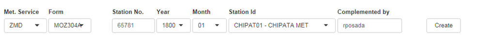

Figura 5. Exemplo da folha `inputs` no aplicativo (exemplo de MOZ304A, ZMD)

O `inputs` pode variar de um formulário para outro e, portanto, o usuário deve ser capaz de modificar ou criar a sua própria folha de `inputs` baseando-se em seus próprios formulários em papel.

Para facilitar isso, o arquivo `.xls` que define a estrutura de um determinado formulário (por exemplo, MOZ304A, ZMD) inclui uma folha denominada `inputs` em que os campos de entrada são descritos (Figura 6).

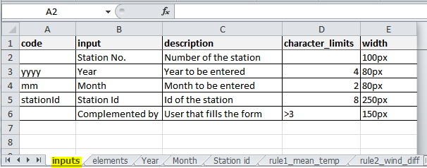

Figura 6. Exemplo de `inputs` folha (MOZ304A, ZMD) (MOZ304A, ZMD)

> **Nota:** Os campos marcados com `*` são obrigatórios.

O usuário pode adicionar tantas entradas como desejado, mas é recomendável inserir apenas aqueles que são necessários para o formulário no papel, de modo que o formulário permaneça semelhante ao documento original em papel.

Para evitar erros ao digitar texto nesses campos, o usuário também pode definir os valores aceitos para cada `input` um em uma folha separada. Por exemplo, se um dos campos de entrada for `ano`, o usuário pode criar uma Planilha chamada `ano` em que os anos são definidos . Então, o usuário terá que selecionar um ano em vez de digitar a data ele mesmo. Isso deve evitar inconsistências no formato da data.

É importante que **o usuário chame a folha com o mesmo nome que o input**, para que o aplicativo possa reconhecer a planilha como informação adicional do input. En caso contrário, o aplicativo ignorará a planilha.

## 7.2 Folha ‘Elementos’

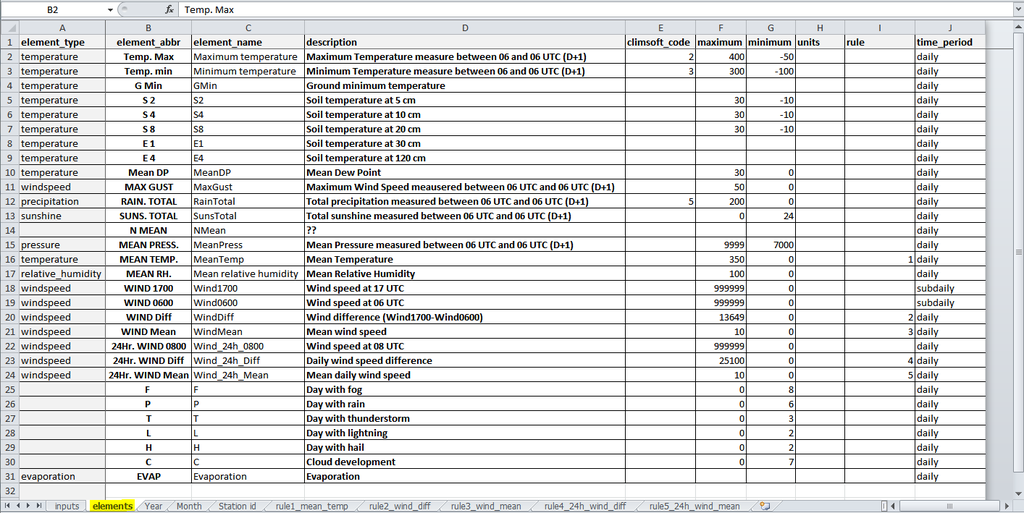

Figura 7. Exemplo de folha `elements` (`MOZ304A`)

Esta folha contém as seguintes informações:

- *element_type*: Tipo de elemento (por exemplo `temperature`, `pressure`, `windspeed`, etc.).
- *element_abbr**: Abreviação do elemento. Esta coluna será usada como cabeçalho para o formulário. Recomenda-se que contenha os mesmos nomes que os usados no formulário em papel
- *element_name*: Nome completo dos elementos
- *description*: Descrição do Elemento
- *climsoft_code*: Código de elemento usado no Climsoft para identificar o elemento. Este código pode ser encontrado na tabela `obs_element` do banco de dados de `MS-Access` do Climsoft, ou na tabela `obsElement` do banco de dados `mariadb` do Climsoft. O código climsoft será usado para transferir os dados do formulário na base de dados de Climsoft
- *maximum*: Valor máximo aceito para um determinado elemento. Ele é usado para verificar se os valores digitalizados estão fora do limite máximo. Se estiver vazio, o aplicativo não poderá verificar se os valores inseridos estão acima deste limite
- *minimum*: Valor mínimo aceito para um determinado elemento. Ele é usado para verificar se os valores digitalizados estão fora do limite mínimo. Se estiver vazio, o aplicativo não poderá verificar se os valores inseridos estão abaixo deste limite
- *units*: unidades do elemento
- *rule*: Um valor numérico que indica que o elemento é calculado com base em outros elementos do formulário. O número é apenas um identificador para saber qual regra deve ser aplicada para calcular o valor. Por favor, verifique as regras na Seção: Definição de regras para mais detalhes
- *time_period**: se o elemento tem um valor diário (`daily`), sub-diário (`subdaily`), anual (`yearly`) ou sub-anual (`subyearly`). Esta informação será útil para transferir os dados para uma base de dados de Climsoft
- *time*: Se o período de tempo for “subdaily”, é necessário especificar a hora exata em que a medida foi feita

> **Nota:** Os campos marcados com `*` são obrigatórios.

## 7.3 Definição de regras

As regras (`rules`) definem a forma de calcular um valor de um elemento com base em outros elementos do formulario. Os valores calculados aparecerão no Formulário automaticamente, e o usuário não poderá substituí-lo. Isto é para garantir que os valores calculados não possam ser modificados manualmente.

Se os valores calculados estiverem errados, o usuário terá que verificar os valores dos outros elementos que foram utilizados para fazer o cálculo.

As regras são definidas previamente pelo usuário no modelo de formulário. Cada regra terá sua própria folha no arquivo `.xls` e o nome dessa planilha deve ser o seguinte:

```
_ruleX_description_
```

Onde *X* é um valor numérico que indica o *rule_id*, e *description* é uma breve descrição do elemento a ser calculado. Por exemplo, *rule1_mean_temp* refere-se à primeira regra (Regra N ° 1 ), que é definida para calcular a temperatura média (*mean temperature*).

Atualmente, existem três tipos diferentes de regras disponíveis:

- *mean*: calcula o valor médio de dois elementos (Figura 8)

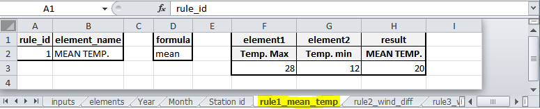

  Figura 8. Cálculo da Temperatura Média com base nas temperaturas mínima e máxima
- *diff*: Calcula a diferença entre dois elementos (Figura 9)

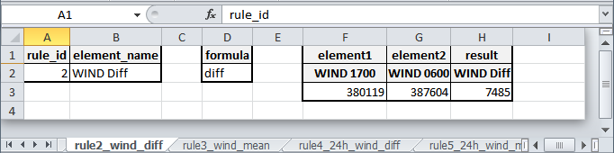

  Figura 9. Cálculo da diferença de velocidade do vento entre a velocidade do vento às 17 UTC e 06 UTC.
- *between*: Dado um valor, ele será verificado em uma tabela (chamada `between_table`) para saber se o valor está entre um certo intervalo de valores. Se assim for, o valor calculado final será um valor definido nessa tabela. A tabela `between_table` deve conter os valores mínimo (`min`) e máximo (`max`) de cada intervalo, e outra coluna com o valor equivalente que será usado como `valor calculado` no final. A Figura 10 mostra um exemplo desta regra

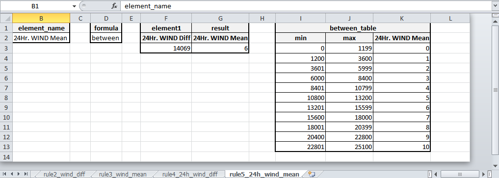

  Figura 10. Cálculo da velocidade média do vento 24h (`24Hr. WIND Mean`) com base no elemento de diferença de vento (`24Hr. Wind Diff`)

Em todos os casos, as folhas `rule` devem conter, pelo menos, as seguintes informações:

- *rule_id*: número da regra. O número deve ser exclusivo e deve corresponder ao número usado na folha `element` na coluna `rule` para definir o elemento de interesse
- *element_name*: Abreviação do elemento que quer ser calculado. Ele deve combinar a abreviatura usada na folha `element`.
- *formula*: Tipo de fórmula utilizada para fazer o cálculo (`mean`, `diff`, ou `between`)

# 8 Criar novo modelo de formulário

O usuário também pode criar um novo modelo completo. Recomenda-se, no entanto, que o usuário aproveite os formulários já existentes para criar seus próprios modelos. Portanto, a recomendação é copiar um formulário antigo e modificá-lo.

Os formulários atualmente disponíveis são organizados por serviço meteorológico e período de tempo. Os modelos de formulário atualmente disponíveis são:

[output not shown]

e estão localizados na pasta:

```
## keyEntry_standalone/keyEntry_App/www/forms
```

Uma vez que o novo modelo foi criado, ele estará automaticamente disponível no `keyEntry_App`.

# 9 Referências

RStudio (2017). *Easy web applications in R*. https://www.rstudio.com/products/shiny/ [último acesso: 11.04.2017]

Wickham (2017). *R Packages*. http://r-pkgs.had.co.nz/intro.html [último acesso: 12.04.2017]

Wikipedia (2017). *Open Database Connectivity*. https://en.wikipedia.org/wiki/Open_Database_Connectivity [último acesso: 11.04.2017]